# HMW 5- Data 621

OMER OZEREN

## Summary

The goal of the homework is to test approaches for evaluating the data set containing various wine characteristics and to predict the number of cases ordered. This project includes comparison of linear, poisson, negative binomial regression models (including zero-inflated negative binomial model).

## Data Exploration

The data set includes 12,795 observations with 14 variables (excluding the target variable).

#### Summary of Variables

Dictionary for Wine Data varianles:

- `AcidIndex`: Proprietary method of testing
- `Alcohol`: Alcohol content of wine.
- `Chlorides`: Chloride content of wine.
- `CitricAcid`: Citric acid content of wine.
- `Density`: Density of wine.
- `FixedAcidity`: Fixed Acidity of wine.
- `FreeSulfurDioxide`: Sulfur dioxide content of wine.
- `LabelAppeal`: Marketing score indicating the appeal of label design for consumers.
- `ResidualSugar`: Residual sugar of wine.
- `STARS`: Wine rating by a team of experts. Ranges from 1 (Poor) to 4 (Excellent) stars.
- `Sulphates`: Sulfate content of wine.
- `TotalSulfurDioxide`: Total sulfur dDioxide of wine.
- `VolatileAcidity`: Volatile acid content of wine.
- `pH`: pH of wine

The SUMMARY of Variables

| Variable | Class | Min | Median | Mean | SD | Max |
| --- | --- | --- | --- | --- | --- | --- |
| FixedAcidity | numeric | -18.1 | 6.9 | 7.076 | 6.318 | 34.4 |
| VolatileAcidity | numeric | -2.79 | 0.28 | 0.3241 | 0.784 | 3.68 |
| CitricAcid | numeric | -3.24 | 0.31 | 0.3084 | 0.8621 | 3.86 |
| ResidualSugar | numeric | -127.8 | 3.9 | 5.419 | 33.75 | 141.2 |
| Chlorides | numeric | -1.171 | 0.046 | 0.05482 | 0.3185 | 1.351 |
| FreeSulfurDioxide | numeric | -555 | 30 | 30.85 | 148.7 | 623 |
| TotalSulfurDioxide | numeric | -823 | 123 | 120.7 | 231.9 | 1057 |
| Density | numeric | 0.8881 | 0.9945 | 0.9942 | 0.02654 | 1.099 |
| pH | numeric | 0.48 | 3.2 | 3.208 | 0.6797 | 6.13 |
| Sulphates | numeric | -3.13 | 0.5 | 0.5271 | 0.9321 | 4.24 |
| Alcohol | numeric | -4.7 | 10.4 | 10.49 | 3.728 | 26.5 |
| LabelAppeal | integer | -2 | 0 | -0.009066 | 0.8911 | 2 |
| AcidIndex | integer | 4 | 8 | 7.773 | 1.324 | 17 |
| STARS | integer | 1 | 2 | 2.042 | 0.9025 | 4 |

| Variable | Num of NAs | Num of Zeros | Num of Neg Values |
| --- | --- | --- | --- |
| FixedAcidity | 0 | 39 | 1621 |
| VolatileAcidity | 0 | 18 | 2827 |
| CitricAcid | 0 | 115 | 2966 |
| ResidualSugar | 616 | 6 | 3136 |
| Chlorides | 638 | 5 | 3197 |
| FreeSulfurDioxide | 647 | 11 | 3036 |
| TotalSulfurDioxide | 682 | 7 | 2504 |
| Density | 0 | 0 | 0 |
| pH | 395 | 0 | 0 |
| Sulphates | 1210 | 22 | 2361 |
| Alcohol | 653 | 2 | 118 |
| LabelAppeal | 0 | 5617 | 3640 |
| AcidIndex | 0 | 0 | 0 |
| STARS | 3359 | 0 | 0 |

Chacteristics of Variables:

All but three independent variables are continous. Variables `LabelAppeal`, `AcidIndex` and `STARS` are categorical, but represented by numeric values in logical order.

#### Missing Values

Majority variables have negative values. Eight variables have some `NA` values. The plot and table below show how the missing values are spread out within the data set. About quarter of observations are missing a `STARS` value. The rest of variables contain missing values for at most 9.5% of observations.

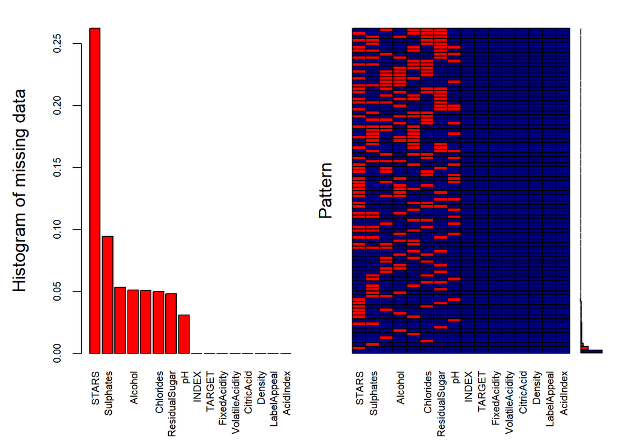

```
##
##  Variables sorted by number of missings:
##            Variable      Count
##               STARS 0.26252442
##           Sulphates 0.09456819
##  TotalSulfurDioxide 0.05330207
##             Alcohol 0.05103556
##   FreeSulfurDioxide 0.05056663
##           Chlorides 0.04986323
##       ResidualSugar 0.04814381
##                  pH 0.03087143
##               INDEX 0.00000000
##              TARGET 0.00000000
##        FixedAcidity 0.00000000
##     VolatileAcidity 0.00000000
##          CitricAcid 0.00000000
##             Density 0.00000000
##         LabelAppeal 0.00000000
##           AcidIndex 0.00000000
```

#### Plots

All dependent variables were inspected using boxplots, density plots and scatterplots. Distribution is similar for all variables - unimodal and symmetrical. Boxplots are also very similar across all possible outcomes with the exception of the last category - 8 cases purchased.

Plots below illustrate results for `Chlorides`.

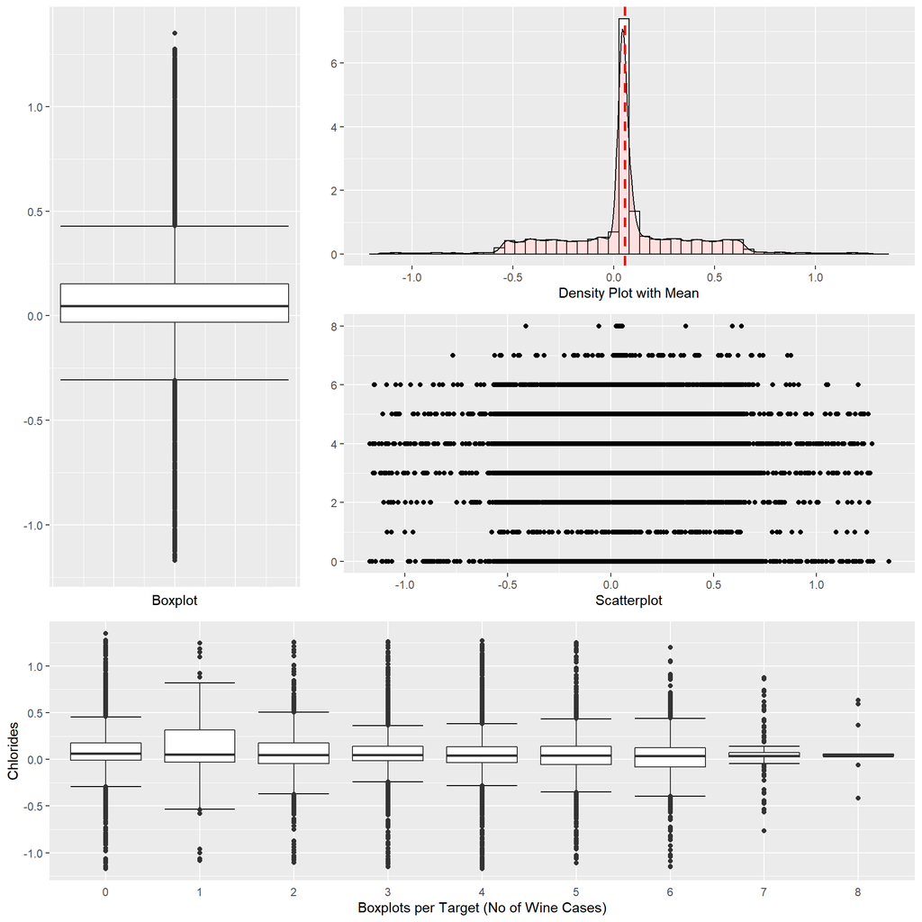

#### Dependent Variable

The dependent variable `TARGET` ranges from 0 (no cases purchased) to 8 cases of wine purchased. The most common outcome is 4 cases at 25% of all observations followed closely with no purchase (0 cases) at 21%. Not counting the 0 outcome, it seems that the variable has unimodal, symmetrical distribution resembling normal distibution centered around 4.

| Outcome | No of Observations | Percent of Total |
| --- | --- | --- |
| 0 | 2734 | 0.21 |
| 1 | 244 | 0.02 |
| 2 | 1091 | 0.09 |
| 3 | 2611 | 0.2 |
| 4 | 3177 | 0.25 |
| 5 | 2014 | 0.16 |
| 6 | 765 | 0.06 |
| 7 | 142 | 0.01 |
| 8 | 17 | 0 |

## Data Preparation

Two main areas to consider are missing and negative values.

#### Missing Values

The `STARS` variables contains 3,359 missing values. It represents ratings. **For this analysis missing values for `STARS` have been replaced with 0.**

Two other categorical variables - `LabelAppeal` and `AcidIndex` - do not have any missing values.

Other variables with missing values are good candidates for imputation. Imputation has been done using the `mice` R package and its method `norm`.

#### Negative Values

`Alcohol` variable has a few negative values - only 118 observations. Negative values for this variable are not possible since 0 would be a non-alcoholic beverage. **The variable has been transformed by taking absolute value of all observations.**

For other variables there is significantly more observations with negative values.

#### Training/Testing Split

Data set has been split into a training (75% of observations) and testing (25% of observations) sets. Splitting has been accomplished using the `caTools` R package based on the `TARGET` variable to make sure that each set has a proportional number of various target classes.

## Modeling: Linear

Two main linear models developed were developed and analyzed. The first one included all available variables. It resulted in R^2 of 0.5268, RMSE of 1.3184 and accuracy in predicting the outcomes in the testing set of 0.2853. The second model used stepwise process in both directions to optimize the model (using the `stepAIC` function). It resulted in R^2 of 0.5266, RMSE of 1.3193 and accuracy of 0.2847. It appears that the full model performed very slightly better than the stepwise model.

Below is the summary of the full model.

```
##
## Call:
## lm(formula = TARGET ~ . - INDEX, data = wineTRAIN)
##
## Residuals:
##     Min      1Q  Median      3Q     Max
## -4.5069 -0.9507  0.0674  0.9089  6.0046
##
## Coefficients:
##                      Estimate Std. Error t value Pr(>|t|)
## (Intercept)         3.674e+00  5.200e-01   7.065 1.72e-12 ***
## FixedAcidity        1.736e-04  2.189e-03   0.079 0.936782
## VolatileAcidity    -9.128e-02  1.732e-02  -5.270 1.39e-07 ***
## CitricAcid          2.278e-02  1.576e-02   1.445 0.148377
## ResidualSugar       1.936e-04  4.040e-04   0.479 0.631779
## Chlorides          -1.148e-01  4.279e-02  -2.682 0.007338 **
## FreeSulfurDioxide   3.203e-04  9.067e-05   3.532 0.000414 ***
## TotalSulfurDioxide  1.077e-04  5.848e-05   1.842 0.065486 .
## Density            -6.009e-01  5.121e-01  -1.173 0.240629
## pH                 -2.453e-02  1.994e-02  -1.230 0.218579
## Sulphates          -3.981e-02  1.456e-02  -2.735 0.006252 **
## Alcohol             1.340e-02  3.763e-03   3.562 0.000370 ***
## LabelAppeal         4.193e-01  1.575e-02  26.618  < 2e-16 ***
## AcidIndex          -2.016e-01  1.068e-02 -18.876  < 2e-16 ***
## STARS               9.832e-01  1.200e-02  81.959  < 2e-16 ***
## ---
## Signif. codes:  0 '***' 0.001 '**' 0.01 '*' 0.05 '.' 0.1 ' ' 1
##
## Residual standard error: 1.326 on 9580 degrees of freedom
## Multiple R-squared:  0.5268, Adjusted R-squared:  0.5261
## F-statistic: 761.7 on 14 and 9580 DF,  p-value: < 2.2e-16
```

Looking at the diagnostic plots we can see that the model performs reasonably well.

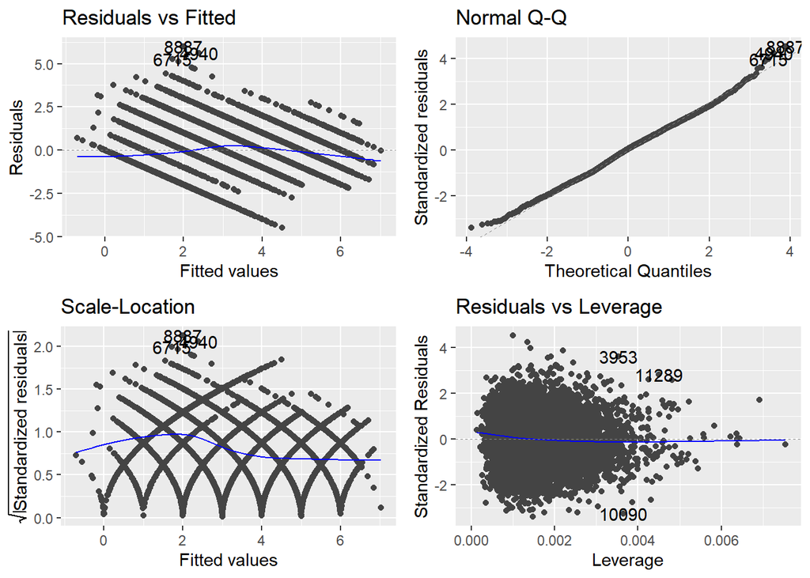

The accuracy is fairly low at 28.53%; however, if we examine full confusion matrix below we can see that the model mostly errors only by 1 or 2 cases which may be reasonable enough for a business application.

```
## Confusion Matrix and Statistics
##
##           Reference
## Prediction   0   1   2   3   4   5   6   7   8
##          0  24   2   1   3   0   0   0   0   0
##          1 313  29  68  80  22   7   0   0   0
##          2 256  26 115 178 109  28  10   2   0
##          3  86   3  74 236 223  71   9   0   0
##          4   5   1  14 129 301 197  42   3   0
##          5   0   0   1  27 128 155  76  14   1
##          6   0   0   0   0  11  45  51  15   1
##          7   0   0   0   0   0   1   3   2   2
##          8   0   0   0   0   0   0   0   0   0
##
## Overall Statistics
##
##                Accuracy : 0.2853
##                  95% CI : (0.2697, 0.3013)
##     No Information Rate : 0.2481
##     P-Value [Acc > NIR] : 8.841e-07
##
##                   Kappa : 0.1642
##
##  Mcnemar's Test P-Value : NA
##
## Statistics by Class:
##
##                      Class: 0 Class: 1 Class: 2 Class: 3 Class: 4 Class: 5
## Sensitivity          0.035088 0.475410  0.42125  0.36141  0.37909  0.30754
## Specificity          0.997615 0.843899  0.79194  0.81704  0.83749  0.90838
## Pos Pred Value       0.800000 0.055877  0.15884  0.33618  0.43497  0.38557
## Neg Pred Value       0.791798 0.988064  0.93619  0.83307  0.80343  0.87527
## Prevalence           0.213750 0.019062  0.08531  0.20406  0.24813  0.15750
## Detection Rate       0.007500 0.009062  0.03594  0.07375  0.09406  0.04844
## Detection Prevalence 0.009375 0.162188  0.22625  0.21937  0.21625  0.12562
## Balanced Accuracy    0.516351 0.659655  0.60659  0.58922  0.60829  0.60796
##                      Class: 6 Class: 7 Class: 8
## Sensitivity           0.26702 0.055556  0.00000
## Specificity           0.97607 0.998104  1.00000
## Pos Pred Value        0.41463 0.250000      NaN
## Neg Pred Value        0.95450 0.989348  0.99875
## Prevalence            0.05969 0.011250  0.00125
## Detection Rate        0.01594 0.000625  0.00000
## Detection Prevalence  0.03844 0.002500  0.00000
## Balanced Accuracy     0.62154 0.526830  0.50000
```

## Modeling: Poisson

The linear model seemed to perform good with all variables. So for the poisson regression similar strategy was applied - a model with all variables and a model optimized by the stepwise method.RMSE for this model is 1.39855, slightly worse than for the linear model.

```
##
## Call:
## glm(formula = TARGET ~ . - INDEX, family = poisson, data = wineTRAIN)
##
## Deviance Residuals:
##     Min       1Q   Median       3Q      Max
## -2.9560  -0.7237   0.0709   0.5750   3.2336
##
## Coefficients:
##                      Estimate Std. Error z value Pr(>|z|)
## (Intercept)         1.416e+00  2.255e-01   6.280 3.40e-10 ***
## FixedAcidity       -2.847e-04  9.536e-04  -0.299 0.765268
## VolatileAcidity    -3.185e-02  7.538e-03  -4.225 2.39e-05 ***
## CitricAcid          8.497e-03  6.825e-03   1.245 0.213161
## ResidualSugar       1.864e-05  1.756e-04   0.106 0.915441
## Chlorides          -3.928e-02  1.860e-02  -2.111 0.034737 *
## FreeSulfurDioxide   1.316e-04  3.924e-05   3.354 0.000797 ***
## TotalSulfurDioxide  4.204e-05  2.562e-05   1.641 0.100760
## Density            -2.169e-01  2.213e-01  -0.980 0.327046
## pH                 -1.222e-02  8.648e-03  -1.413 0.157722
## Sulphates          -1.571e-02  6.336e-03  -2.479 0.013185 *
## Alcohol             3.316e-03  1.642e-03   2.020 0.043396 *
## LabelAppeal         1.298e-01  6.997e-03  18.553  < 2e-16 ***
## AcidIndex          -8.412e-02  5.256e-03 -16.004  < 2e-16 ***
## STARS               3.133e-01  5.187e-03  60.395  < 2e-16 ***
## ---
## Signif. codes:  0 '***' 0.001 '**' 0.01 '*' 0.05 '.' 0.1 ' ' 1
##
## (Dispersion parameter for poisson family taken to be 1)
##
##     Null deviance: 17142  on 9594  degrees of freedom
## Residual deviance: 11060  on 9580  degrees of freedom
## AIC: 35045
##
## Number of Fisher Scoring iterations: 5
```

Confusion matrix below comparing predicted values to the test data shows that the model does not predict *no purchase* outcome (count is 0).Accuracy is lower than for the linear model.

```
## Accuracy
## 0.233125
```

```
##           Reference
## Prediction   0   1   2   3   4   5   6   7   8   9  10
##         0    0   0   0   0   0   0   0   0   0   0   0
##         1  204  19  35  39   6   4   0   0   0   0   0
##         2  421  38 166 282 178  45  12   2   0   0   0
##         3   58   4  64 231 305 118  12   1   0   0   0
##         4    1   0   6  75 186 155  36   2   0   0   0
##         5    0   0   2  24  94 103  53  11   1   0   0
##         6    0   0   0   2  18  53  32   6   0   0   0
##         7    0   0   0   0   5  19  28   9   1   0   0
##         8    0   0   0   0   2   6  17   4   0   0   0
##         9    0   0   0   0   0   1   0   1   2   0   0
##         10   0   0   0   0   0   0   1   0   0   0   0
```

## Modeling: Negative Binomial

Using the `MASS` R package, negative binomial model was created using all variables. This model turned out to be nearly identical to the poisson model.

## Modeling: Zero-Inflated Negative Binomial

Poisson and negative binomial models do not account for the 0 outcome. So a zero-inflated negative binomial model was attempted using the `pscl` R package. RMSE for this model is 1.2727, the best one out of all models.

```
##
## Call:
## zeroinfl(formula = TARGET ~ . - INDEX, data = wineTRAIN, dist = "negbin")
##
## Pearson residuals:
##       Min        1Q    Median        3Q       Max
## -2.105450 -0.406781 -0.007306  0.370589  5.885163
##
## Count model coefficients (negbin with log link):
##                      Estimate Std. Error z value Pr(>|z|)
## (Intercept)         1.387e+00  2.329e-01   5.957 2.57e-09 ***
## FixedAcidity        3.228e-04  9.820e-04   0.329 0.742387
## VolatileAcidity    -1.187e-02  7.783e-03  -1.526 0.127118
## CitricAcid          2.758e-03  7.006e-03   0.394 0.693862
## ResidualSugar      -1.059e-04  1.812e-04  -0.584 0.558888
## Chlorides          -2.436e-02  1.911e-02  -1.274 0.202495
## FreeSulfurDioxide   1.724e-05  3.963e-05   0.435 0.663490
## TotalSulfurDioxide -3.882e-05  2.549e-05  -1.523 0.127695
## Density            -2.332e-01  2.280e-01  -1.023 0.306351
## pH                  3.883e-03  8.915e-03   0.436 0.663155
## Sulphates          -1.098e-03  6.521e-03  -0.168 0.866280
## Alcohol             7.189e-03  1.679e-03   4.282 1.85e-05 ***
## LabelAppeal         2.321e-01  7.276e-03  31.891  < 2e-16 ***
## AcidIndex          -1.777e-02  5.663e-03  -3.137 0.001707 **
## STARS               1.028e-01  5.964e-03  17.238  < 2e-16 ***
## Log(theta)          1.694e+01  4.783e+00   3.541 0.000399 ***
##
## Zero-inflation model coefficients (binomial with logit link):
##                      Estimate Std. Error z value Pr(>|z|)
## (Intercept)        -4.4586261  1.5648921  -2.849 0.004383 **
## FixedAcidity       -0.0002330  0.0064138  -0.036 0.971025
## VolatileAcidity     0.1521666  0.0500158   3.042 0.002347 **
## CitricAcid         -0.0168785  0.0463039  -0.365 0.715474
## ResidualSugar      -0.0014052  0.0011789  -1.192 0.233247
## Chlorides          -0.0439761  0.1239205  -0.355 0.722685
## FreeSulfurDioxide  -0.0009264  0.0002715  -3.412 0.000644 ***
## TotalSulfurDioxide -0.0007884  0.0001692  -4.659 3.18e-06 ***
## Density             0.6548048  1.5366155   0.426 0.670010
## pH                  0.1873836  0.0580400   3.229 0.001244 **
## Sulphates           0.1280396  0.0425675   3.008 0.002630 **
## Alcohol             0.0233215  0.0110156   2.117 0.034249 *
## LabelAppeal         0.7547617  0.0495577  15.230  < 2e-16 ***
## AcidIndex           0.4345239  0.0300666  14.452  < 2e-16 ***
## STARS              -2.3833651  0.0698008 -34.145  < 2e-16 ***
## ---
## Signif. codes:  0 '***' 0.001 '**' 0.01 '*' 0.05 '.' 0.1 ' ' 1
##
## Theta = 22639264.4045
## Number of iterations in BFGS optimization: 36
## Log-likelihood: -1.53e+04 on 31 Df
```

```
## Accuracy
## 0.358125
```

```
##           Reference
## Prediction   0   1   2   3   4   5   6   7   8
##          0 107   1   0   6   4   3   1   1   0
##          1 323  15  34  76  39  16   5   1   0
##          2 138  36 125 117  39  11   4   0   0
##          3 103   9 107 309 246  64   4   0   0
##          4  13   0   7 140 373 200  33   3   0
##          5   0   0   0   5  81 164  75  11   0
##          6   0   0   0   0  12  36  45  12   0
##          7   0   0   0   0   0  10  20   8   4
##          8   0   0   0   0   0   0   4   0   0
```

## Model Comparison

Considering log-likelihood of all models, it is clear that zero-inflated negative binomial model is the best option. More research in that direction will probably be beneficial.

|  | Log-Likelihood | DF |
| --- | --- | --- |
| **Linear** | -16316 | 16 |
| **Poisson** | -17507 | 15 |
| **NB** | -17507 | 16 |
| **ZINB** | -15303 | 31 |

|  | Linear | Poisson | NB | ZINB (Count) |
| --- | --- | --- | --- | --- |
| **(Intercept)** | 3.674 | 1.416 | 1.416 | 1.387 |
| **FixedAcidity** | 0.000174 | -0.000285 | -0.000285 | 0.000323 |
| **VolatileAcidity** | -0.09128 | -0.03185 | -0.03185 | -0.01187 |
| **CitricAcid** | 0.02278 | 0.008497 | 0.008497 | 0.002758 |
| **ResidualSugar** | 0.000194 | 1.9e-05 | 1.9e-05 | -0.000106 |
| **Chlorides** | -0.1148 | -0.03928 | -0.03928 | -0.02436 |
| **FreeSulfurDioxide** | 0.00032 | 0.000132 | 0.000132 | 1.7e-05 |
| **TotalSulfurDioxide** | 0.000108 | 4.2e-05 | 4.2e-05 | -3.9e-05 |
| **Density** | -0.6009 | -0.2169 | -0.2169 | -0.2332 |
| **pH** | -0.02453 | -0.01222 | -0.01222 | 0.003883 |
| **Sulphates** | -0.03981 | -0.01571 | -0.01571 | -0.001098 |
| **Alcohol** | 0.0134 | 0.003316 | 0.003316 | 0.007189 |
| **LabelAppeal** | 0.4193 | 0.1298 | 0.1298 | 0.2321 |
| **AcidIndex** | -0.2016 | -0.08412 | -0.08412 | -0.01777 |
| **STARS** | 0.9832 | 0.3133 | 0.3133 | 0.1028 |

## APPENDIX A: Evaluation Data Set

Please note that this appendix includes first 100 observations from the evaluation set.

| Index | Predicted Value | Predicted Outcome |
| --- | --- | --- |
| 3 | 1.894 | 2 |
| 9 | 3.826 | 4 |
| 10 | 2.513 | 3 |
| 18 | 2.492 | 2 |
| 21 | 0.7127 | 1 |
| 30 | 5.695 | 6 |
| 31 | 3.595 | 4 |
| 37 | 1.343 | 1 |
| 39 | 0.2309 | 0 |
| 47 | 1.467 | 1 |
| 60 | 2.693 | 3 |
| 62 | 0.2158 | 0 |
| 63 | 3.539 | 4 |
| 64 | 1.329 | 1 |
| 68 | 1.176 | 1 |
| 75 | 2.761 | 3 |
| 76 | 2.517 | 3 |
| 83 | 0.0539 | 0 |
| 87 | 3.674 | 4 |
| 92 | 5.435 | 5 |
| 98 | 2.317 | 2 |
| 106 | 1.682 | 2 |
| 107 | 0.473 | 0 |
| 113 | 2.537 | 3 |
| 120 | 3.448 | 3 |
| 123 | 5.88 | 6 |
| 125 | 2.838 | 3 |
| 126 | 5.872 | 6 |
| 128 | 4.508 | 5 |
| 129 | 2.449 | 2 |

[output cut: 70 more lines]